# TS_HW3_Liang_Gong

2025-01-30

```r
library(fpp3)
library(dplyr)
```

**3.7 Consider the last five years of the Gas data from aus_production.**

**a. Plot the time series. Can you identify seasonal fluctuations and/or a trend-cycle?**

The line graph exhibits a clear cyclical pattern, with peaks and troughs occurring at regular intervals. This suggests the presence of seasonal fluctuations in gas production.

There is trend in the data, where the general direction of the series is upwards over the years, despite the regular seasonal ups and downs.

```r
# Consider the last five years of the Gas data
gas <- tail(aus_production, 5 * 4) %>% select(Gas)
```

```r
view(gas)
```

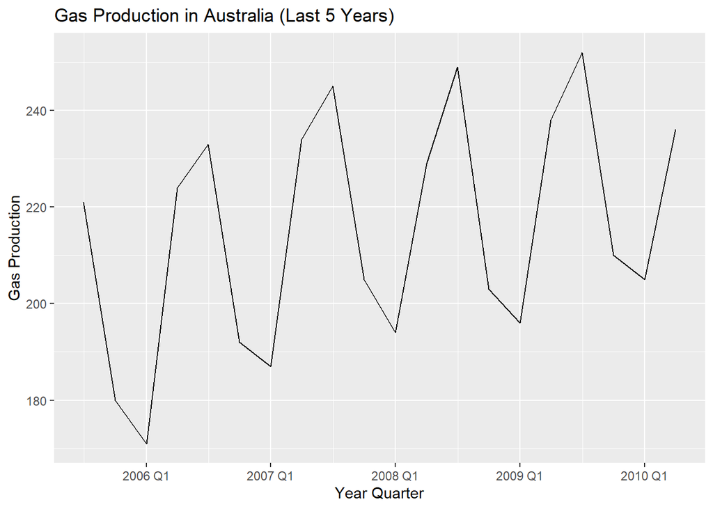

```r
# Plot the time series.
autoplot(gas, Gas) +
  labs(title = "Gas Production in Australia (Last 5 Years)",
       y = "Gas Production",
       x = "Year Quarter")
```

**b. Use classical_decomposition with type=multiplicative to calculate the trend-cycle and seasonal indices.**

The season_adjust column in the decomposition result is the seasonally adjusted series, which is calculated by removing the seasonal component from the original series. Mathematically:season_adjust=Gas/seasonal. This column represents the data with the seasonal variation eliminated, helping to analyze the underlying trend and other components without seasonal effects. It is especially useful for identifying trends and irregularities in the data.

```r
decomposition <- gas %>%
  model(classical_decomposition(Gas, type = "multiplicative"))
```

```r
components <- decomposition %>%
  components()

view(components)
```

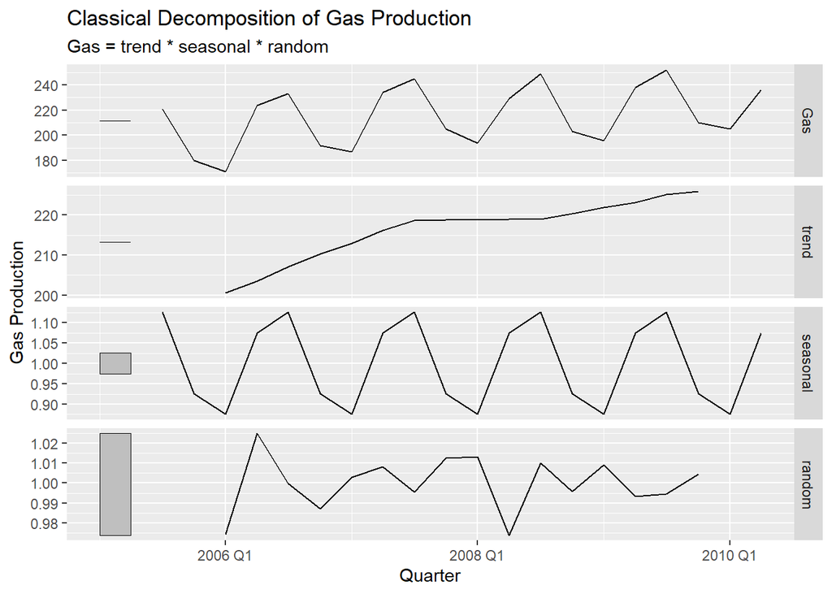

```r
# Plot the decomposed components (trend, seasonal, remainder)
autoplot(components) +
  labs(title = "Classical Decomposition of Gas Production",
       y = "Gas Production")
```

**c. Do the results support the graphical interpretation from part a?**

Yes.

The classical multiplicative decomposition reveals the following insights:

- **Trend Component**: Shows an upward trend, indicating an overall increase in gas production over time, aligning with earlier graphical observations.
- **Seasonal Component**: Captures consistent seasonal patterns with regular peaks and troughs each year, confirming the seasonality identified in the data.
- **Random Component**: Represents unexplained variability, appearing stable without obvious patterns, indicating successful extraction of trend and seasonal effects.

Overall, the decomposition confirms both an increasing trend and clear seasonal fluctuations in Australian gas production.

**d. Compute and plot the seasonally adjusted data.**

Seasonal adjustment removes the regular seasonal fluctuations, providing a clearer view of the underlying trend. This adjustment helps focus on the trend and long-term changes in gas production, eliminating the recurring seasonal effects seen in the original data.

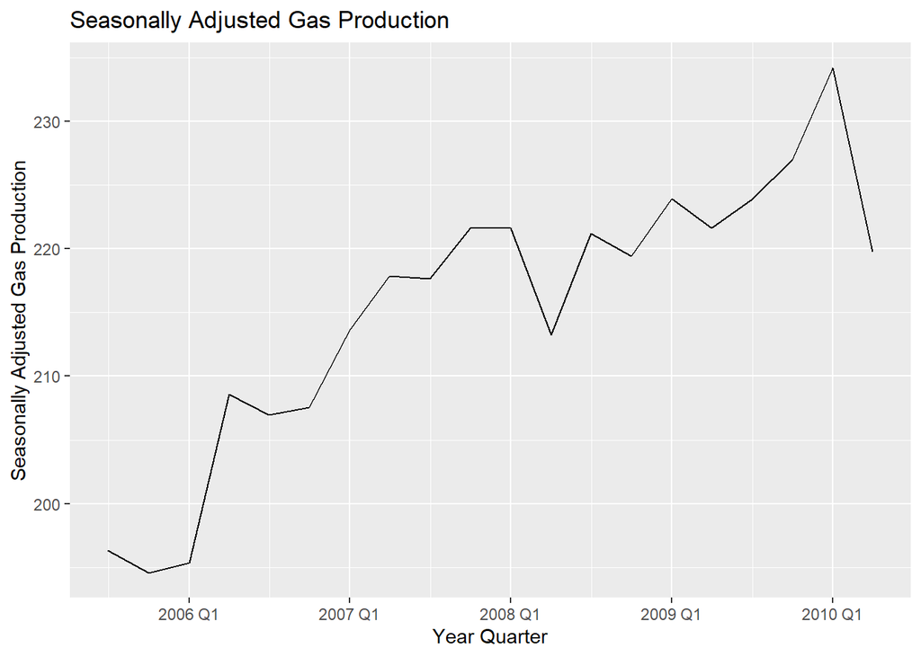

```r
gas %>%
  model(classical_decomposition(Gas, type="multiplicative")) |>
  components() |>
  as_tsibble() |>
  autoplot(season_adjust) +
  labs(title = "Seasonally Adjusted Gas Production",
       y = "Seasonally Adjusted Gas Production",
       x = "Year Quarter")
```

**e. Change one observation to be an outlier (e.g., add 300 to one observation), and recompute the seasonally adjusted data. What is the effect of the outlier?**

The introduction of an outlier by adding 300 to the gas production value in 2007 Q2 significantly impacts the seasonally adjusted data:

- **Spike in Data**: A noticeable spike appears in 2007 Q2, deviating substantially from surrounding values.
- **Distortion**: The outlier distorts the seasonally adjusted data, making it less representative of the true underlying trend.
- **Impact on Components**: The trend and seasonal components are affected as the model adjusts to accommodate the outlier, leading to potential inaccuracies.
- **Biased Analysis**: The outlier introduces distortions that can mislead conclusions about the trend and seasonal patterns.

In summary, the outlier disrupts the analysis, emphasizing the importance of identifying and handling anomalies for accurate time series interpretations.

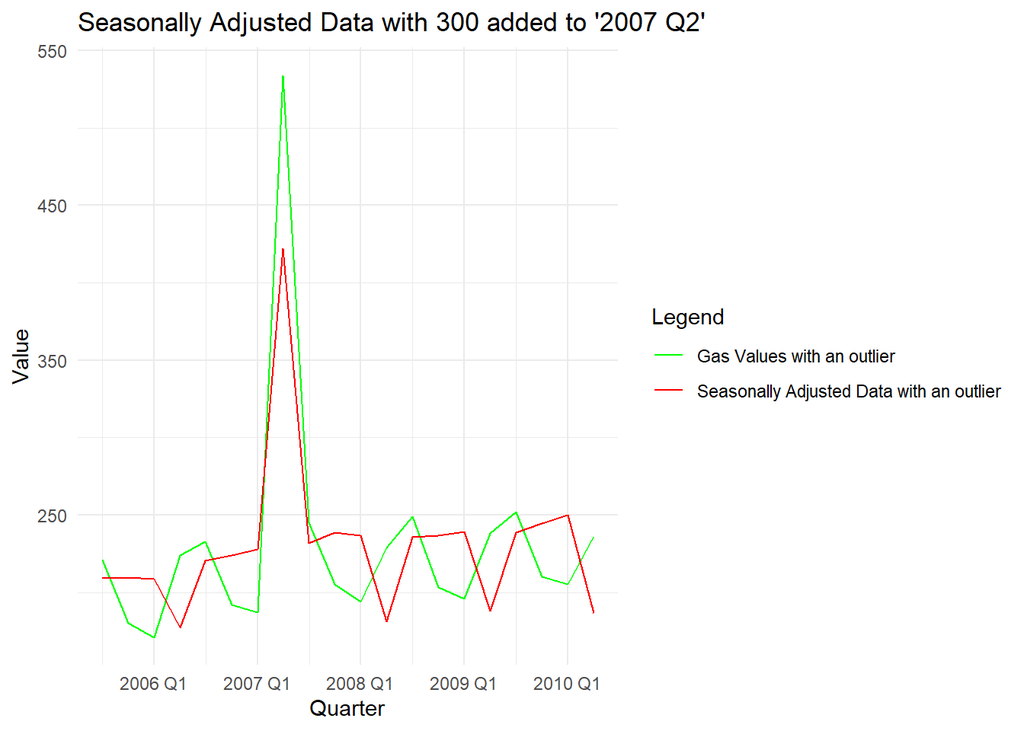

```r
gas %>%
  mutate(Gas = if_else(Quarter == yearquarter("2007Q2"), Gas + 300, Gas)) %>%
  model(classical_decomposition(Gas, type = "multiplicative")) %>%
  components() %>%
  as_tsibble() %>%
  ggplot() +
  geom_line(aes(x = Quarter, y = Gas, colour = "Gas Values with an outlier")) +
  geom_line(aes(x = Quarter, y = season_adjust, colour = "Seasonally Adjusted Data with an outlier")) +
  labs(title = "Seasonally Adjusted Data with 300 added to '2007 Q2'",
       x = "Quarter",
       y = "Value",
       colour = "Legend") +
  scale_colour_manual(values = c("Gas Values with an outlier" = "green", "Seasonally Adjusted Data with an outlier" = "red")) +
  theme_minimal()
```

**f. Does it make any difference if the outlier is near the end rather than in the middle of the time series?**

When the outlier is introduced later in the time series (e.g., 2010Q1), the spike appears closer to the later part of the data. This placement causes a noticeable but localized deviation in the adjusted series at that specific point.

The earlier part of the time series seems less unaffected by this outlier, allowing the trend to develop more naturally before the outlier’s impact is seen.

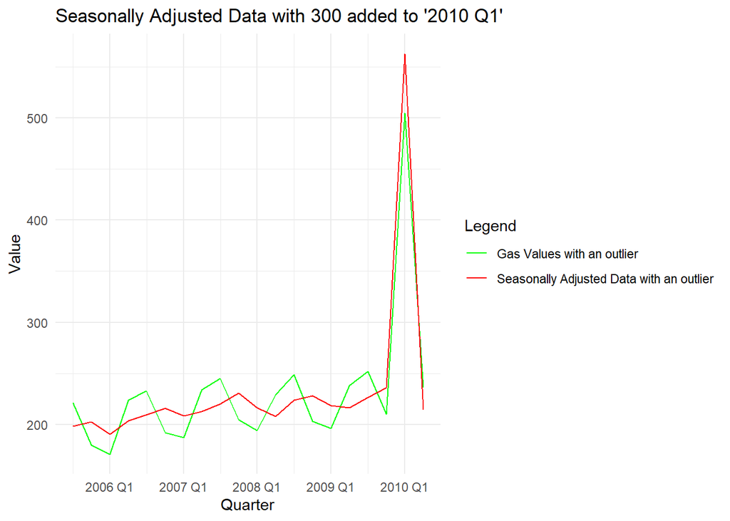

```r
gas %>%
  mutate(Gas = if_else(Quarter == yearquarter("2010Q1"), Gas + 300, Gas)) %>%
  model(classical_decomposition(Gas, type = "multiplicative")) %>%
  components() %>%
  as_tsibble() %>%
  ggplot() +
  geom_line(aes(x = Quarter, y = Gas, colour = "Gas Values with an outlier")) +
  geom_line(aes(x = Quarter, y = season_adjust, colour = "Seasonally Adjusted Data with an outlier")) +
  labs(title = "Seasonally Adjusted Data with 300 added to '2010 Q1'",
       x = "Quarter",
       y = "Value",
       colour = "Legend") +
  scale_colour_manual(values = c("Gas Values with an outlier" = "green", "Seasonally Adjusted Data with an outlier" = "red")) +
  theme_minimal()
```

**10.2 Repeat Exercise 4 from Section 7.10, but this time adding in ARIMA errors to address the autocorrelations in the residuals.**

The data set souvenirs concerns the monthly sales figures of a shop which opened in January 1987 and sells gifts, souvenirs, and novelties. The shop is situated on the wharf at a beach resort town in Queensland, Australia. The sales volume varies with the seasonal population of tourists. There is a large influx of visitors to the town at Christmas and for the local surfing festival, held every March since 1988. Over time, the shop has expanded its premises, range of products, and staff.

**a. How much difference does the ARIMA error process make to the regression coefficients?**

**Effect of ARIMA Errors on Regression Coefficients:**

1. **Trend Coefficient (trend()):**  
   **TSLM model:** `0.02239`  
   **TSLM with ARIMA errors:** `0.0225`  
   **Minimal change**, indicating the overall trend estimate is stable.
2. **Seasonal Coefficients:**  
   Most seasonal estimates **slightly decrease** with ARIMA errors, e.g.,:  
   **season(year3):** `0.6952` → `0.6875`  
   **season(year7):** `0.6082` → `0.6002`  
   **season(year12):** `1.9581` → `1.9511`  
   This suggests **some autocorrelation was captured by the ARIMA process**, slightly adjusting seasonal effects.
3. **Intercept:**  
   **TSLM model:** `7.6059`  
   **TSLM with ARIMA errors:** `7.6107`  
   **Very small increase**, indicating no major structural shift.
4. **Overall Impact:**  
   The regression coefficients remain **largely similar** but are **slightly adjusted** as the ARIMA model absorbs some autocorrelation.  
   **ARIMA(0,0,2) errors (MA terms)** help reduce residual autocorrelation, making the model more reliable.

**Key Takeaway:**

The ARIMA error process does **not drastically change** the regression coefficients but **refines them** by accounting for residual dependencies. It ensures both systematic (trend and seasonality) and stochastic (autocorrelations) components of the time series are modeled effectively, resulting in better forecasts.

```r
View(souvenirs)
```

```r
install.packages("fable")
library(fable)
```

```r
options(repos = c(CRAN = "https://cran.rstudio.com/"))
install.packages("tidyverse")
library(tidyverse)
# Fit a TSLM model (linear model) with trend and seasonal components.
tslm_model <- souvenirs %>%
  model(TSLM(Sales ~ trend() + season()))

# Fit a TSLM model to the log-transformed sales data.
# log_tslm_model assumes independent residuals.
log_tslm_model <- souvenirs %>%
  model(TSLM(log(Sales) ~ trend() + season()))
```

```r
glance(log_tslm_model)
```

```
## # A tibble: 1 × 15
##   .model   r_squared adj_r_squared sigma2 statistic  p_value    df log_lik   AIC
##   <chr>        <dbl>         <dbl>  <dbl>     <dbl>    <dbl> <int>   <dbl> <dbl>
## 1 TSLM(lo…     0.953         0.945 0.0345      119. 5.09e-42    13    29.2 -269.
## # ℹ 6 more variables: AICc <dbl>, BIC <dbl>, CV <dbl>, deviance <dbl>,
## #   df.residual <int>, rank <int>
```

```r
report(log_tslm_model)
```

```
## Series: Sales
## Model: TSLM
## Transformation: log(Sales)
##
## Residuals:
##       Min        1Q    Median        3Q       Max
## -0.416437 -0.126185  0.006075  0.113889  0.385670
##
## Coefficients:
##                 Estimate Std. Error t value Pr(>|t|)
## (Intercept)    7.6058604  0.0768740  98.939  < 2e-16 ***
## trend()        0.0223930  0.0008448  26.508  < 2e-16 ***
## season()year2  0.2510437  0.0993278   2.527 0.013718 *
## season()year3  0.6952066  0.0993386   6.998 1.18e-09 ***
## season()year4  0.3829341  0.0993565   3.854 0.000252 ***
## season()year5  0.4079944  0.0993817   4.105 0.000106 ***
## season()year6  0.4469625  0.0994140   4.496 2.63e-05 ***
## season()year7  0.6082156  0.0994534   6.116 4.69e-08 ***
## season()year8  0.5853524  0.0995001   5.883 1.21e-07 ***
## season()year9  0.6663446  0.0995538   6.693 4.27e-09 ***
## season()year10 0.7440336  0.0996148   7.469 1.61e-10 ***
## season()year11 1.2030164  0.0996828  12.068  < 2e-16 ***
## season()year12 1.9581366  0.0997579  19.629  < 2e-16 ***
## ---
## Signif. codes:  0 '***' 0.001 '**' 0.01 '*' 0.05 '.' 0.1 ' ' 1
##
## Residual standard error: 0.1858 on 71 degrees of freedom
## Multiple R-squared: 0.9527,  Adjusted R-squared: 0.9447
## F-statistic: 119.1 on 12 and 71 DF, p-value: < 2.22e-16
```

log_tslm_arima_model

The **log-transformed TSLM model with ARIMA(0,0,2) errors** can be written as:

$$\log(Sales_t) = 7.6107 + 0.0225 \cdot t + \sum_{i=2}^{12} \beta_i \cdot
\text{season}_i + \epsilon_t$$

Where: - $t$ is the time trend. - $\beta_i$ are the seasonal coefficients: - $\beta_2 = 0.2486$, $\beta_3 = 0.6875$, …, $\beta_{12} = 1.9511$. - $\epsilon_t$ follows an **ARIMA(0,0,2) error process**:
$$\epsilon_t = e_t + 0.3569 e_{t-1} + 0.5543 e_{t-2}$$
where $e_t$ is white noise.

This equation incorporates both the **trend + seasonality** and **ARIMA(0,0,2) errors** to account for autocorrelation.

```r
# Fit a TSLM model with ARIMA errors (i.e., Regression with ARIMA Errors) in fable, use the ARIMA() function for modeling the residuals
# It models log-transformed Sales using a linear trend, seasonal effects, and ARIMA errors to handle autocorrelation in the residuals.
log_tslm_arima_model <- souvenirs %>%
  model(ARIMA(log(Sales) ~ trend() + season()))
```

```r
report(log_tslm_arima_model)
```

```
## Series: Sales
## Model: LM w/ ARIMA(0,0,2) errors
## Transformation: log(Sales)
##
## Coefficients:
##          ma1     ma2  trend()  season()year2  season()year3  season()year4
##       0.3569  0.5543   0.0225         0.2486         0.6875         0.3751
## s.e.  0.0869  0.0994   0.0012         0.0682         0.0680         0.0874
##       season()year5  season()year6  season()year7  season()year8  season()year9
##              0.4001         0.4390         0.6002         0.5773         0.6582
## s.e.         0.0874         0.0874         0.0874         0.0875         0.0876
##       season()year10  season()year11  season()year12  intercept
##               0.7358          1.1954          1.9511     7.6107
## s.e.          0.0877          0.0705          0.0702     0.0766
##
## sigma^2 estimated as 0.02309:  log likelihood=46.95
## AIC=-61.9   AICc=-53.78   BIC=-23.01
```

```r
# Extract coefficients using tidy() for comparison.
log_tslm_model_coefficients <- tidy(log_tslm_model)
log_tslm_arima_model_coefficients <- tidy(log_tslm_arima_model)

print("log_tslm_model Coefficients:")
```

```
## [1] "log_tslm_model Coefficients:"
```

```r
print(log_tslm_model_coefficients)
```

```
## # A tibble: 13 × 6
##    .model                            term  estimate std.error statistic  p.value
##    <chr>                             <chr>    <dbl>     <dbl>     <dbl>    <dbl>
##  1 TSLM(log(Sales) ~ trend() + seas… (Int…   7.61    0.0769       98.9  8.19e-78
##  2 TSLM(log(Sales) ~ trend() + seas… tren…   0.0224  0.000845     26.5  1.48e-38
##  3 TSLM(log(Sales) ~ trend() + seas… seas…   0.251   0.0993        2.53 1.37e- 2
##  4 TSLM(log(Sales) ~ trend() + seas… seas…   0.695   0.0993        7.00 1.18e- 9
##  5 TSLM(log(Sales) ~ trend() + seas… seas…   0.383   0.0994        3.85 2.52e- 4
##  6 TSLM(log(Sales) ~ trend() + seas… seas…   0.408   0.0994        4.11 1.06e- 4
##  7 TSLM(log(Sales) ~ trend() + seas… seas…   0.447   0.0994        4.50 2.63e- 5
##  8 TSLM(log(Sales) ~ trend() + seas… seas…   0.608   0.0995        6.12 4.69e- 8
##  9 TSLM(log(Sales) ~ trend() + seas… seas…   0.585   0.0995        5.88 1.21e- 7
## 10 TSLM(log(Sales) ~ trend() + seas… seas…   0.666   0.0996        6.69 4.27e- 9
## 11 TSLM(log(Sales) ~ trend() + seas… seas…   0.744   0.0996        7.47 1.61e-10
## 12 TSLM(log(Sales) ~ trend() + seas… seas…   1.20    0.0997       12.1  7.22e-19
## 13 TSLM(log(Sales) ~ trend() + seas… seas…   1.96    0.0998       19.6  2.12e-30
```

```r
print("log_tslm_arima_model Coefficients:")
```

```
## [1] "log_tslm_arima_model Coefficients:"
```

```r
print(log_tslm_arima_model_coefficients)
```

```
## # A tibble: 15 × 6
##    .model                            term  estimate std.error statistic  p.value
##    <chr>                             <chr>    <dbl>     <dbl>     <dbl>    <dbl>
##  1 ARIMA(log(Sales) ~ trend() + sea… ma1     0.357    0.0869       4.11 9.30e- 5
##  2 ARIMA(log(Sales) ~ trend() + sea… ma2     0.554    0.0994       5.57 2.95e- 7
##  3 ARIMA(log(Sales) ~ trend() + sea… tren…   0.0225   0.00117     19.3  1.52e-32
##  4 ARIMA(log(Sales) ~ trend() + sea… seas…   0.249    0.0682       3.64 4.64e- 4
##  5 ARIMA(log(Sales) ~ trend() + sea… seas…   0.688    0.0680      10.1  3.58e-16
##  6 ARIMA(log(Sales) ~ trend() + sea… seas…   0.375    0.0874       4.29 4.68e- 5
##  7 ARIMA(log(Sales) ~ trend() + sea… seas…   0.400    0.0874       4.58 1.60e- 5
##  8 ARIMA(log(Sales) ~ trend() + sea… seas…   0.439    0.0874       5.02 2.82e- 6
##  9 ARIMA(log(Sales) ~ trend() + sea… seas…   0.600    0.0874       6.86 1.07e- 9
## 10 ARIMA(log(Sales) ~ trend() + sea… seas…   0.577    0.0875       6.60 3.52e- 9
## 11 ARIMA(log(Sales) ~ trend() + sea… seas…   0.658    0.0876       7.52 5.61e-11
## 12 ARIMA(log(Sales) ~ trend() + sea… seas…   0.736    0.0877       8.39 9.86e-13
## 13 ARIMA(log(Sales) ~ trend() + sea… seas…   1.20     0.0705      17.0  7.64e-29
## 14 ARIMA(log(Sales) ~ trend() + sea… seas…   1.95     0.0702      27.8  4.14e-44
## 15 ARIMA(log(Sales) ~ trend() + sea… inte…   7.61     0.0766      99.3  7.24e-89
```

**b. How much difference does the ARIMA error process make to the forecasts?**

**Analysis of the Difference (TSLM - TSLM_ARIMA):**

**Conclusion**:

The ARIMA error process (TSLM_ARIMA) generally produces **slightly higher forecasts** than TSLM, with differences averaging around $-87.77$. However, most differences are small, with occasional significant deviations. The ARIMA error process makes a noticeable difference to the forecasts by slightly adjusting the forecast values, generally leading to narrower confidence intervals, and potentially improving the overall forecast accuracy by accounting for the time series data’s autocorrelation and non-stationarity.

```r
# Forecast horizon (e.g., next 36 months)
horizon <- 36

# Forecast from TSLM model
log_tslm_forecast <- log_tslm_model %>%
  forecast(h = horizon)

# Forecast from TSLM with ARIMA errors model
log_tslm_arima_forecast <- log_tslm_arima_model %>%
  forecast(h = horizon)
```

```r
# Convert forecasts back to original scale
# Transform the forecasted values from log scale back to the original scale by exponentiating them. This reverses the log(Sales) transformation used in the model.
tslm_forecast_original <- log_tslm_forecast %>%
  mutate(.mean = exp(.mean))

tslm_arima_forecast_original <- log_tslm_arima_forecast %>%
  mutate(.mean = exp(.mean))
```

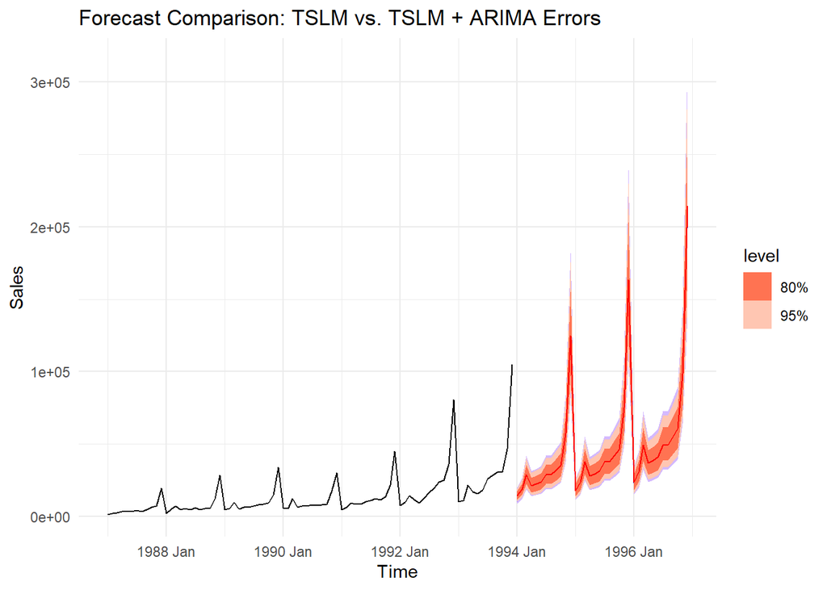

```r
# Plot forecasts from both models
autoplot(souvenirs, Sales) +
  autolayer(tslm_forecast_original, series = "TSLM Forecast", color = "blue") +
  autolayer(tslm_arima_forecast_original, series = "TSLM + ARIMA Errors Forecast", color = "red") +
  labs(title = "Forecast Comparison: TSLM vs. TSLM + ARIMA Errors",
       y = "Sales", x = "Time") +
  theme_minimal()
```

```r
print(log_tslm_forecast)
```

```
## # A fable: 36 x 4 [1M]
## # Key:     .model [1]
##    .model                                   Month            Sales  .mean
##    <chr>                                    <mth>           <dist>  <dbl>
##  1 TSLM(log(Sales) ~ trend() + season()) 1994 Jan t(N(9.5, 0.041)) 13761.
##  2 TSLM(log(Sales) ~ trend() + season()) 1994 Feb t(N(9.8, 0.041)) 18089.
##  3 TSLM(log(Sales) ~ trend() + season()) 1994 Mar  t(N(10, 0.041)) 28842.
##  4 TSLM(log(Sales) ~ trend() + season()) 1994 Apr  t(N(10, 0.041)) 21584.
##  5 TSLM(log(Sales) ~ trend() + season()) 1994 May  t(N(10, 0.041)) 22633.
##  6 TSLM(log(Sales) ~ trend() + season()) 1994 Jun  t(N(10, 0.041)) 24066.
##  7 TSLM(log(Sales) ~ trend() + season()) 1994 Jul  t(N(10, 0.041)) 28917.
##  8 TSLM(log(Sales) ~ trend() + season()) 1994 Aug  t(N(10, 0.041)) 28903.
##  9 TSLM(log(Sales) ~ trend() + season()) 1994 Sep  t(N(10, 0.041)) 32051.
## 10 TSLM(log(Sales) ~ trend() + season()) 1994 Oct  t(N(10, 0.041)) 35425.
## # ℹ 26 more rows
```

```r
print(log_tslm_arima_forecast)
```

```
## # A fable: 36 x 4 [1M]
## # Key:     .model [1]
##    .model                                    Month            Sales  .mean
##    <chr>                                     <mth>           <dist>  <dbl>
##  1 ARIMA(log(Sales) ~ trend() + season()) 1994 Jan t(N(9.6, 0.023)) 14540.
##  2 ARIMA(log(Sales) ~ trend() + season()) 1994 Feb t(N(9.8, 0.026)) 18792.
##  3 ARIMA(log(Sales) ~ trend() + season()) 1994 Mar  t(N(10, 0.033)) 28833.
##  4 ARIMA(log(Sales) ~ trend() + season()) 1994 Apr  t(N(10, 0.033)) 21577.
##  5 ARIMA(log(Sales) ~ trend() + season()) 1994 May  t(N(10, 0.033)) 22625.
##  6 ARIMA(log(Sales) ~ trend() + season()) 1994 Jun  t(N(10, 0.033)) 24057.
##  7 ARIMA(log(Sales) ~ trend() + season()) 1994 Jul  t(N(10, 0.033)) 28907.
##  8 ARIMA(log(Sales) ~ trend() + season()) 1994 Aug  t(N(10, 0.033)) 28894.
##  9 ARIMA(log(Sales) ~ trend() + season()) 1994 Sep  t(N(10, 0.033)) 32040.
## 10 ARIMA(log(Sales) ~ trend() + season()) 1994 Oct  t(N(10, 0.033)) 35413.
## # ℹ 26 more rows
```

```r
# Convert forecasts to tibbles and extract the required columns
# as_tibble(): Converts fable objects into standard tibbles, which allow regular operations like bind_cols()
tslm_forecast_tibble <- log_tslm_forecast %>%
  as_tibble() %>%
  select(Month, .mean) %>%
  rename(TSLM = .mean)

tslm_arima_forecast_tibble <- log_tslm_arima_forecast %>%
  as_tibble() %>%
  select(.mean) %>%
  rename(TSLM_ARIMA = .mean)

# Combine the tibbles side by side
forecast_comparison <- bind_cols(tslm_forecast_tibble, tslm_arima_forecast_tibble)

forecast_comparison <- forecast_comparison %>%
  mutate(Difference = TSLM - TSLM_ARIMA)

# Print the comparison
print(forecast_comparison)
```

```
## # A tibble: 36 × 4
##       Month   TSLM TSLM_ARIMA Difference
##       <mth>  <dbl>      <dbl>      <dbl>
##  1 1994 Jan 13761.     14540.    -779.
##  2 1994 Feb 18089.     18792.    -703.
##  3 1994 Mar 28842.     28833.       9.74
##  4 1994 Apr 21584.     21577.       7.60
##  5 1994 May 22633.     22625.       7.94
##  6 1994 Jun 24066.     24057.       8.19
##  7 1994 Jul 28917.     28907.      10.3
##  8 1994 Aug 28903.     28894.       9.35
##  9 1994 Sep 32051.     32040.      11.9
## 10 1994 Oct 35425.     35413.      12.1
## # ℹ 26 more rows
```

```r
summary(forecast_comparison$Difference)
```

```
##     Min.  1st Qu.   Median     Mean  3rd Qu.     Max.
## -778.815 -113.916  -17.321  -87.769   -2.583   12.061
```

**c. Check the residuals of the fitted model to ensure the ARIMA process has adequately addressed the autocorrelations seen in the TSLM model.**

Based on the attached residual diagnostics:

- **Time Plot**: Residuals show no clear patterns or trends, indicating randomness.
- **ACF Plot**: All autocorrelations fall within the confidence bounds, suggesting no significant autocorrelation remains.
- **Histogram**: Residuals appear approximately normally distributed.

## **Conclusion**:

The ARIMA process has adequately addressed the autocorrelations. Residuals behave like white noise, indicating a well-fitted model.

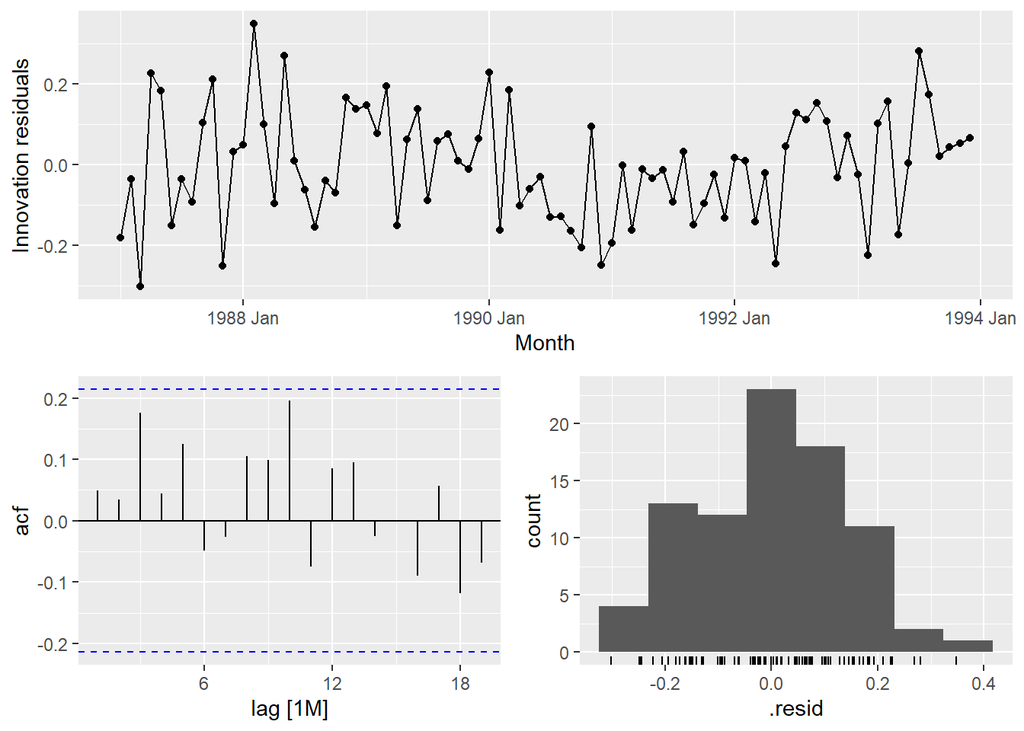

```r
# Check residuals of the fitted model
library(feasts)  # Ensure feasts package is loaded for gg_tsresiduals()

gg_tsresiduals(log_tslm_arima_model)
```

p-value > 0.05, residuals are likely uncorrelated (good fit).

```r
library(feasts)  # Ensure feasts is loaded
library(fabletools)  # For residual extraction

# Extract residuals from the ARIMA model
residuals <- residuals(log_tslm_arima_model)

# Perform the Ljung-Box test
# Model includes 2 estimated parameters (ma1 and ma2) from the ARIMA(0,0,2) process, so dof=2.
ljung_box_result <- residuals %>%
  features(.resid, ljung_box, lag = 10, dof = 2)

# Print the results
print(ljung_box_result)
```

```
## # A tibble: 1 × 3
##   .model                                 lb_stat lb_pvalue
##   <chr>                                    <dbl>     <dbl>
## 1 ARIMA(log(Sales) ~ trend() + season())    10.7     0.220
```